# Regression_3

### End-to-End Regression

[figure not shown]

#### 1. Get the Data

```python
import pandas as pd

data = pd.read_csv('housing.csv') # California Housing Prices
data.head()
```

|  | longitude | latitude | housing_median_age | total_rooms | total_bedrooms | population | households | median_income | median_house_value | ocean_proximity |
| --- | --- | --- | --- | --- | --- | --- | --- | --- | --- | --- |
| 0 | -122.23 | 37.88 | 41.0 | 880.0 | 129.0 | 322.0 | 126.0 | 8.3252 | 452600.0 | NEAR BAY |
| 1 | -122.22 | 37.86 | 21.0 | 7099.0 | 1106.0 | 2401.0 | 1138.0 | 8.3014 | 358500.0 | NEAR BAY |
| 2 | -122.24 | 37.85 | 52.0 | 1467.0 | 190.0 | 496.0 | 177.0 | 7.2574 | 352100.0 | NEAR BAY |
| 3 | -122.25 | 37.85 | 52.0 | 1274.0 | 235.0 | 558.0 | 219.0 | 5.6431 | 341300.0 | NEAR BAY |
| 4 | -122.25 | 37.85 | 52.0 | 1627.0 | 280.0 | 565.0 | 259.0 | 3.8462 | 342200.0 | NEAR BAY |

```python
data.info()
# total_bedrooms has only 20,433 non-null values meaning that 207 districts, need to take care of this
# ocean_proximity is a categorical attribute
```

```
<class 'pandas.core.frame.DataFrame'>
RangeIndex: 20640 entries, 0 to 20639
Data columns (total 10 columns):
longitude             20640 non-null float64
latitude              20640 non-null float64
housing_median_age    20640 non-null float64
total_rooms           20640 non-null float64
total_bedrooms        20433 non-null float64
population            20640 non-null float64
households            20640 non-null float64
median_income         20640 non-null float64
median_house_value    20640 non-null float64
ocean_proximity       20640 non-null object
dtypes: float64(9), object(1)
memory usage: 1.6+ MB
```

```python
# check categorical attribute
data["ocean_proximity"].value_counts()
```

```
<1H OCEAN     9136
INLAND        6551
NEAR OCEAN    2658
NEAR BAY      2290
ISLAND           5
Name: ocean_proximity, dtype: int64
```

```python
# show a summary of the numerical attributes
data.describe()
```

|  | longitude | latitude | housing_median_age | total_rooms | total_bedrooms | population | households | median_income | median_house_value |
| --- | --- | --- | --- | --- | --- | --- | --- | --- | --- |
| count | 20640.000000 | 20640.000000 | 20640.000000 | 20640.000000 | 20433.000000 | 20640.000000 | 20640.000000 | 20640.000000 | 20640.000000 |
| mean | -119.569704 | 35.631861 | 28.639486 | 2635.763081 | 537.870553 | 1425.476744 | 499.539680 | 3.870671 | 206855.816909 |
| std | 2.003532 | 2.135952 | 12.585558 | 2181.615252 | 421.385070 | 1132.462122 | 382.329753 | 1.899822 | 115395.615874 |
| min | -124.350000 | 32.540000 | 1.000000 | 2.000000 | 1.000000 | 3.000000 | 1.000000 | 0.499900 | 14999.000000 |
| 25% | -121.800000 | 33.930000 | 18.000000 | 1447.750000 | 296.000000 | 787.000000 | 280.000000 | 2.563400 | 119600.000000 |
| 50% | -118.490000 | 34.260000 | 29.000000 | 2127.000000 | 435.000000 | 1166.000000 | 409.000000 | 3.534800 | 179700.000000 |
| 75% | -118.010000 | 37.710000 | 37.000000 | 3148.000000 | 647.000000 | 1725.000000 | 605.000000 | 4.743250 | 264725.000000 |
| max | -114.310000 | 41.950000 | 52.000000 | 39320.000000 | 6445.000000 | 35682.000000 | 6082.000000 | 15.000100 | 500001.000000 |

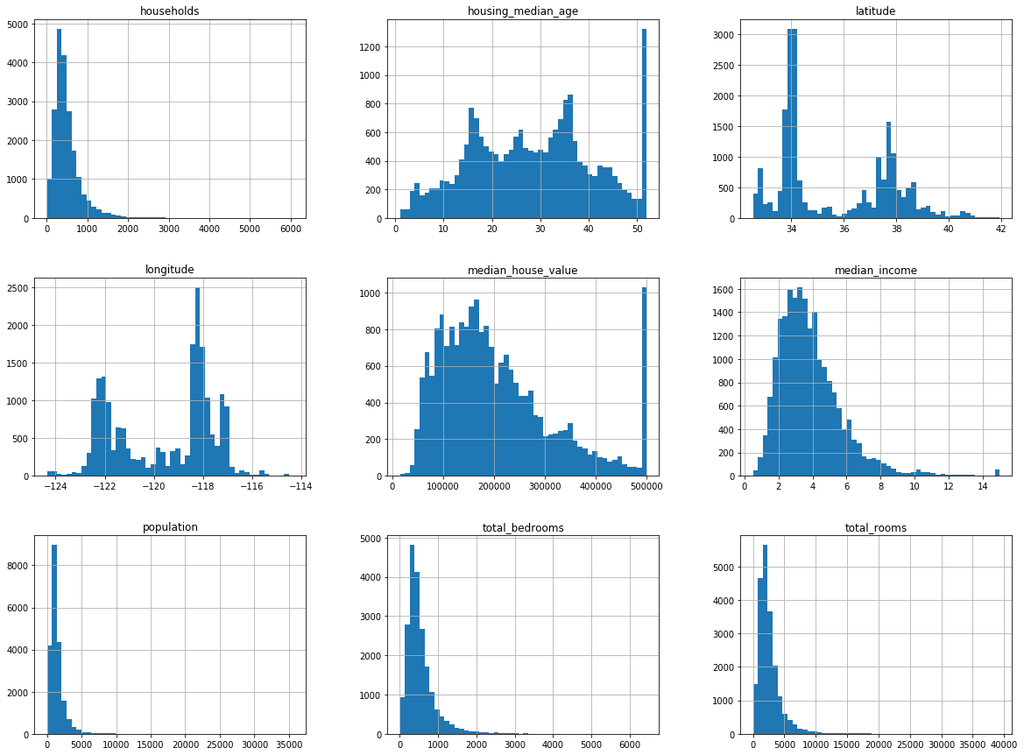

```python
plots = data.hist(bins = 50, figsize = (20, 15))
```

#### 2. Discover and visualize the data to gain insights

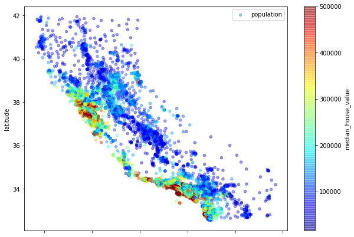

```python
import matplotlib.pyplot as plt
x = data['longitude']
y = data['latitude']
data.plot(kind='scatter', x='longitude', y='latitude', alpha=0.4, label='population', figsize=(10, 7), c='median_house_value', cmap=plt.get_cmap('jet'), colorbar=True)
```

```python
# Add more Attributie Combinations which have higher Correlation with median_house_value
data_copy = data.copy()
data_copy["rooms_per_household"] = data_copy["total_rooms"]/data_copy["households"]
data_copy["bedrooms_per_room"] = data_copy["total_bedrooms"]/data_copy["total_rooms"]
data_copy["population_per_household"]=data_copy["population"]/data_copy["households"]
```

```python
# Looking for Correlations or Use scatter_matrix
corr_matrix = data_copy.corr()
corr_matrix['median_house_value']
```

```
longitude                  -0.045967
latitude                   -0.144160
housing_median_age          0.105623
total_rooms                 0.134153
total_bedrooms              0.049686
population                 -0.024650
households                  0.065843
median_income               0.688075
median_house_value          1.000000
rooms_per_household         0.151948
bedrooms_per_room          -0.255880
population_per_household   -0.023737
Name: median_house_value, dtype: float64
```

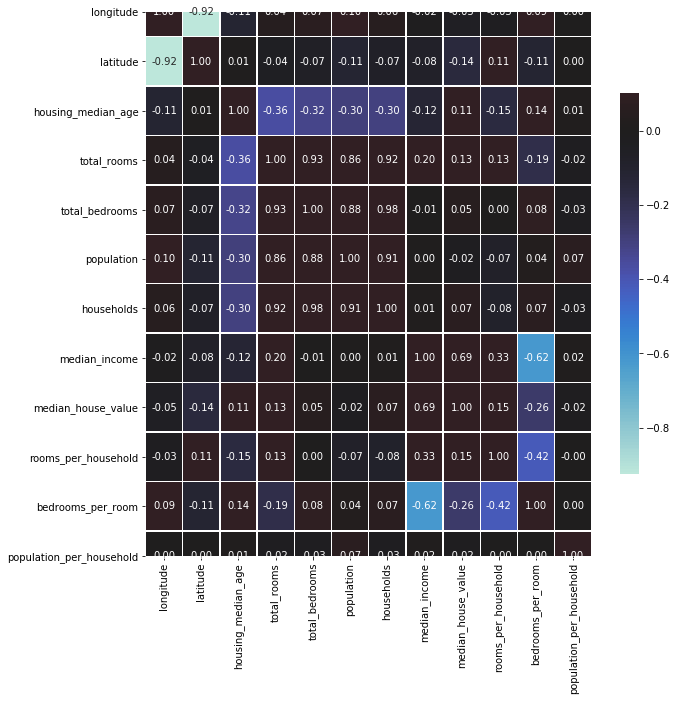

```python
# Looking for Correlations or Use scatter_matrix
corr_matrix = data_copy.corr()

import seaborn as sns
fig, ax = plt.subplots(figsize=(10,10))
sns.heatmap(corr_matrix, vmax=0.1, center=0, fmt='.2f',
                square=False, linewidths=.5, annot=True, cbar_kws={"shrink": 0.7}, ax = ax)
```

#### Feature Selection

- the process of selecting the attributes that can make the predicted variable more accurate or eliminating those attributes that are irrelevant and can decrease the model accuracy and quality

#### [Data Correlation](https://towardsdatascience.com/why-feature-correlation-matters-a-lot-847e8ba439c4)

- Correlation can help in predicting one attribute from another
- Correlation can (sometimes) indicate the presence of a causal relationship
- Correlation is used as a basic quantity for many modelling techniques
- If your dataset has perfectly positive or negative attributes, the performance of the model will be impacted by multicollinearity. Luckily, decision trees and boosted trees algorithms are immune to multicollinearity by nature.
  - The easiest way is to delete or eliminate one of the perfectly correlated features
  - use a dimension reduction algorithm such as Principle Component Analysis (PCA)

#### Correlation

- Pearson Correlation Coefficient, used with continuous variables that have a linear relationship
- Spearman Correlation Coefficient, used with variable that have a non-linear relationship

#### 3. Prepare Training Set and Test Set

```python
# Read Data
data = pd.read_csv('housing.csv')

# Create Training Set and Test Set

from sklearn.model_selection import train_test_split
# train_test_split
# test_size, ratio of test set
# train_size, ratio of trainning set
# random_state, random seed
# shuffle, whether or not to shuffle the data before splitting
# stratify, data is split in a stratified fashion

import numpy as np
data_X = data.drop(['median_house_value'], axis = 1) # DataFrame
data_Y = data['median_house_value'] # Series

# split the dataset by categories of median income
data['income_cat'] = np.ceil(data['median_income']/1.5)
data['income_cat'].where(data['income_cat'] < 5, 5, inplace=True)

train_X, test_X, train_Y, test_Y = train_test_split(data_X, data_Y, test_size=0.2, random_state=42, stratify = data['income_cat'])
```

#### 4. Prepare the Data for Machine Learning Algorithms

```python
#Custom Transformer, add three features

from sklearn.base import BaseEstimator, TransformerMixin

class AddAttributes(BaseEstimator, TransformerMixin):
    def __init__(self): # no *args or **kargs
        pass
    def fit(self, X, y=None):
        return self  # nothing else to do
    def transform(self, X):
        X["rooms_per_household"] = X["total_rooms"]/X["households"]
        X["bedrooms_per_room"] = X["total_bedrooms"]/X["total_rooms"]
        X["population_per_household"]=X["population"]/X["households"]
        return X
```

```python
train_X_num = train_X.drop("ocean_proximity", axis=1)
attr_adder = AddAttributes()
temp = attr_adder.transform(data_num)
```

```python
# Data Cleaning
from sklearn.impute import SimpleImputer

imputer = SimpleImputer(strategy="median")
temp_2 = imputer.fit_transform(train_X_num)
```

```python
# Convert Text and Categorical Attributes to Dummy Attributes
from sklearn.preprocessing import LabelBinarizer

encoder = LabelBinarizer()
temp_3 = encoder.fit_transform(train_X['ocean_proximity'])
```

#### Scaling variables

- zero-mean normalization: $x_{i}=(x_{i}−mean(x_{i}))/std(x_{i})$, standardization
- Min-max normalization: $x_{i}=(x_{i}−min(x_{i})/(max(x_{i})−min(x_{i}))$ normalizaiton, recommendation

```python
# feature scaling
from sklearn.preprocessing import MinMaxScaler

scaler = MinMaxScaler()
temp_4 = scaler.fit_transform(train_X_num)
```

#### Transformation Pipelines

```python
class DataFrameSelector(BaseEstimator, TransformerMixin):
    def __init__(self, attribute_names):
        self.attribute_names = attribute_names
    def fit(self, X, y=None):
        return self
    def transform(self, X):
        return X[self.attribute_names]
```

```python
# Create Pipeline for Numeric Columns
from sklearn.pipeline import Pipeline
from sklearn.impute import SimpleImputer
from sklearn.preprocessing import StandardScaler

num_pipeline = Pipeline([
    ("select_numeric", DataFrameSelector(['longitude','latitude','housing_median_age','total_rooms','total_bedrooms','population','households','median_income',])),
    ('attribs_adder', AddAttributes()),
    ('imputer', SimpleImputer(strategy="median")),
    ('std_scaler', StandardScaler()),
])

#train_X_tr = num_pipeline.fit_transform(train_X)
```

```python
# Create Pipeline for Categorical Columns
from sklearn.preprocessing import OneHotEncoder

cat_pipeline = Pipeline([
    ("select_numeric", DataFrameSelector(['ocean_proximity'])),
    ('cat', OneHotEncoder()),
])

#data_cat_tr = cat_pipeline.fit_transform(train_X)
```

```python
# Merge Numeric Columns and Categorical Columns
from sklearn.pipeline import FeatureUnion

preprocess_pipeline = FeatureUnion(transformer_list=[
        ("num_pipeline", num_pipeline),
        ("cat_pipeline", cat_pipeline),
    ])
```

```python
train_X = preprocess_pipeline.fit_transform(train_X).toarray()
```

#### 5. Select and Train a Model

- Do not spending too much time tweaking the hyperparameters, the goal is to shortlist a few promissing models

```python
models = [] # save models

from sklearn.linear_model import LinearRegression
models.append(LinearRegression()) # linear regression model

from sklearn.tree import DecisionTreeRegressor
models.append(DecisionTreeRegressor(random_state=42)) # decision tree model

from sklearn.ensemble import RandomForestRegressor # random forest model
models.append(RandomForestRegressor())

from sklearn.svm import SVR
models.append(SVR(kernel="linear")) # Support Vector Regression model
```

```python
from sklearn.model_selection import cross_val_score

def cross_validation(model, X, Y, k = 10):
    scores = cross_val_score(model, X, Y, scoring='neg_mean_squared_error', cv = k);
    return np.sqrt(-scores).mean(), np.sqrt(-scores).std() # represent perforance and precision respectively
```

```python
for model in models:
    mean, std = cross_validation(model, train_X, train_Y, 10)
    print(mean, std)
```

```
68480.58471553595 2845.5843092650834
71035.2888883461 2456.17961798448
```

```
52547.86132487167 1771.793006493265
111711.14888265522 2754.3053045240267
```

#### 6. Fine-Tune Your Model

- Select a couple of models having reasonable performance from above
- Fine-tune these models to generate the best model

#### Grid Search

```python
from sklearn.model_selection import GridSearchCV

param_grid = [{'n_estimators': [40, 50, 100], 'max_features': [2, 4, 6, 8, 10, 12]}]

grid_search = GridSearchCV(RandomForestRegressor(), param_grid, cv=5, scoring='neg_mean_squared_error')

grid_search.fit(train_X, train_Y)
```

[output not shown]

```python
grid_search.best_params_ # best combination of parameters
```

```
{'max_features': 8, 'n_estimators': 100}
```

```python
grid_search.best_estimator_ # best model
# If GridSearchCV is initialized with refit=Ture (which is the default),
# then once it finds the best estimator using cross-validation, it retrains it on the whole training set
```

```
RandomForestRegressor(bootstrap=True, criterion='mse', max_depth=None,
                      max_features=8, max_leaf_nodes=None,
                      min_impurity_decrease=0.0, min_impurity_split=None,
                      min_samples_leaf=1, min_samples_split=2,
                      min_weight_fraction_leaf=0.0, n_estimators=100,
                      n_jobs=None, oob_score=False, random_state=None,
                      verbose=0, warm_start=False)
```

```python
# evaluation scores
cvres = grid_search.cv_results_
for mean_score, params in zip(cvres["mean_test_score"], cvres["params"]):
    print(np.sqrt(-mean_score), params)
```

[output not shown]

#### Randomized Search

```python
# Select a random combination of hyperparameter at every iteration
from sklearn.model_selection import RandomizedSearchCV

param_random = {'n_estimators': [50, 100, 150], 'max_features': [2, 4, 6, 8, 10, 12]}

random_search = RandomizedSearchCV(RandomForestRegressor(), param_random, cv=5, scoring='neg_mean_squared_error', n_iter = 10)

random_search.fit(train_X, train_Y)
```

```
RandomizedSearchCV(cv=5, error_score='raise-deprecating',
                   estimator=RandomForestRegressor(bootstrap=True,
                                                   criterion='mse',
                                                   max_depth=None,
                                                   max_features='auto',
                                                   max_leaf_nodes=None,
                                                   min_impurity_decrease=0.0,
                                                   min_impurity_split=None,
                                                   min_samples_leaf=1,
                                                   min_samples_split=2,
                                                   min_weight_fraction_leaf=0.0,
                                                   n_estimators='warn',
                                                   n_jobs=None, oob_score=False,
                                                   random_state=None, verbose=0,
                                                   warm_start=False),
                   iid='warn', n_iter=10, n_jobs=None,
                   param_distributions={'max_features': [2, 4, 6, 8, 10, 12],
                                        'n_estimators': [50, 100, 150]},
                   pre_dispatch='2*n_jobs', random_state=None, refit=True,
                   return_train_score=False, scoring='neg_mean_squared_error',
                   verbose=0)
```

```python
random_search.best_params_ # best combination of parameters
```

```
{'n_estimators': 150, 'max_features': 6}
```

```python
cvres = random_search.cv_results_
for mean_score, params in zip(cvres["mean_test_score"], cvres["params"]):
    print(np.sqrt(-mean_score), params)
```

```
51728.70993263402 {'n_estimators': 100, 'max_features': 2}
49499.19408833201 {'n_estimators': 50, 'max_features': 8}
49636.25379861854 {'n_estimators': 50, 'max_features': 6}
49410.96742527571 {'n_estimators': 150, 'max_features': 10}
49115.81496692589 {'n_estimators': 150, 'max_features': 6}
49582.48906382619 {'n_estimators': 100, 'max_features': 10}
49781.290845521806 {'n_estimators': 100, 'max_features': 12}
52282.97103341898 {'n_estimators': 50, 'max_features': 2}
49761.92632748126 {'n_estimators': 150, 'max_features': 12}
50217.99942408262 {'n_estimators': 50, 'max_features': 4}
```

#### 7. Ensemble Methods

#### 8. Analyze the Best Models and Their Errors

```python
# Look at the specific errors, try to understand why it makes them and what could fix the problem,
# e.g., adding extra features or getting rid of uninformative ones, cleaning up outliers
feature_importance = grid_search.best_estimator_.feature_importances_
l = zip(feature_importance, data_X.columns)
for e in l:
    print(e)
```

[output not shown]

#### 9. Train Final Model

```python
final_model = grid_search.best_estimator_
#final_model.fit(train_X, train_Y) # Do not have to retain, it has been done by GridSearchCV or RandomizedSearchCV
```

#### 10. Evaluate System on the Test Set

```python
test_X = preprocess_pipeline.transform(test_X).toarray()
```

```python
# Evaluate test dataset
from sklearn.metrics import mean_squared_error

predictions = final_model.predict(test_X)

MSE = mean_squared_error(test_Y, predictions)
RMSE = np.sqrt(MSE)
RMSE
```

```
47081.741234699286
```

```python
# 95% confidence interval for the generalizaiton error
from scipy import stats

confidence = 0.95
squared_errors = (predictions - test_Y) ** 2
np.sqrt(stats.t.interval(confidence, len(squared_errors) - 1,
                         loc=squared_errors.mean(),
                         scale=stats.sem(squared_errors)))
```

```
array([45096.96449215, 48986.16650623])
```

#### 11. Deliver Model

```python
import pickle

f = open('model.pkl', 'wb');
pickle.dump(final_model, f, -1);
```

```python
import joblib

jolib.dump(final_model, 'model.pkl')

#model_loaded = joblib.load('model.pkl')
```

#### Reference

- [Hands-on Notebook](https://github.com/ageron/handson-ml2)